# Praca Domowa 5

Aleksander Podsiad

## Opis:

Celem tej pracy domowej było zbadanie, jaki wpływ na poprawny odczyt danych ma forma wykresu. W [ankiecie internetowej](https://forms.gle/q8gH6S4CN8QqhJoe7) przeprowadzonej wśród 31 osób znajdowały się trzy różne wykresy przedstawiające te same dane w inny sposób oraz pytania sprawdzające postrzeganie danych z tych wykresów oraz samych wykresów.

## Wyniki ankiety:

### Dla wykresu kołowego

64% ankietowanych stwierdziło, że jabłek jest więcej niż pomarańczy na podstawie poniższego wykresu. Jest to odpowiedź błędna*. Przyczyną takiego postrzegania wykresu jest nieumiejętność dokładnego ocenienia kątów i powierzchni przez ludzkie oko oraz dodatkowe zaburzenie proporcji wynikające z obrotu wykresu.

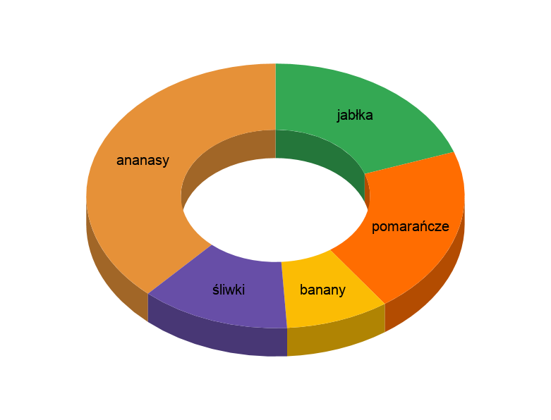

##### *Ilości owoców: jabłka - 40, pomarańcze - 42, banany - 18, śliwki - 26, ananasy - 78

### Dla wykresu liniowego

Przy zadaniu tego samego pytania do poniższego wykresu już ponad 90% ankietowanych jest w stanie podać poprawną odpowiedź. Jednak, gdy zapytamy o stosunek liczby jabłek do liczby ananasów, to tylko około 20% odpowiadających widzi zachodzącą zależność. Problem w ocenie tworzy tutaj brak osi (i pewności czy wykres zaczyna się od zera) oraz trudność porównania proporcji wysokości dwóch punktów. W przeciwieństwie do poprzedniego wykresu bardzo łatwo stwierdzić, która wartość jest większa.

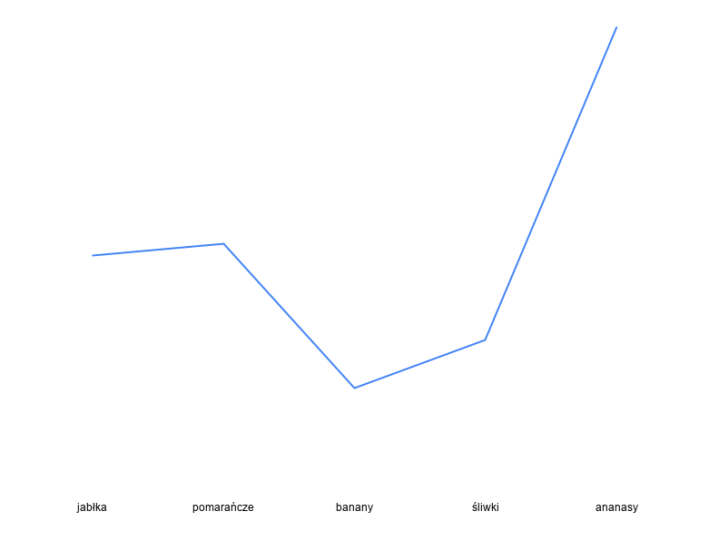

### Dla wykresu słupkowego

Poniższy wykres ułatwia ocenę nie tylko różnic ilości owoców, ale również pozwala poprawnie ocenić ich wzajemne proporcje. Dzieje się tak, ponieważ ludzkie oko o wiele lepiej ocenia stosunki długości elementów, takich jak na przykład słupki. Oprócz tego na wykresie umieszczono sitkę pionowych linii dodatkowo ułatwiających odczytywanie wartości.

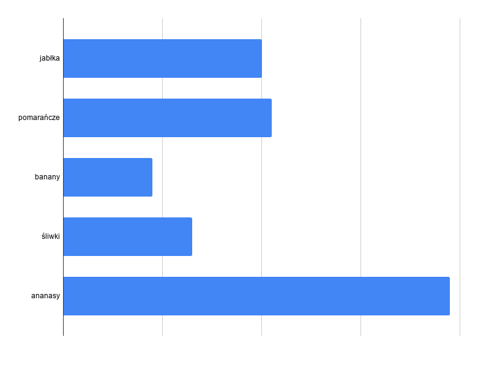

## Podsumowanie

Należy odpowiednio dobierać typ wykresu do danych. Powinno się unikać wykresów kołowych, a na pewno nie używać ich w wersji 3D. Trzeba też pamiętać, żeby dostosować sposób przedstawienia do prezentowanych zależności (nie tworzyć skali ciągłej dla wartości dyskretnych). Wykres słupkowy umożliwia najdokładniejszy odczyt danych i jest najlepiej odbieraną formą przekazu informacji.